# Part II - FORD BIKE SYSTEM DATA

## by Osigah Ogedegbe

## Investigation Overview

> The data set that included information about individual rides made in a bike-sharing system covering the greater San Francisco Bay area was analysed and one theme that i want to highlight here is the differences between the bike users which are the subscribers and the customers.

## Dataset Overview

> This data set includes information about individual rides made in a bike-sharing system covering the greater San Francisco Bay area.https://video.udacity-data.com/topher/2020/October/5f91cf38_201902-fordgobike-tripdata/201902-fordgobike-tripdata.csv

## Percentage of User types

> The Pie chart illustrates the percentages of both user types. There are 183,412 rows contained in the bike share dataset and we find there are a large percentage of subscribers in the program to customers who are not enrolled in the program.

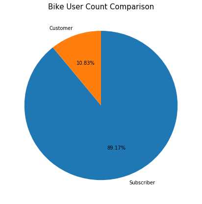

## Usage of Service based on day of the week

> This service is used more on weekdays than weekends

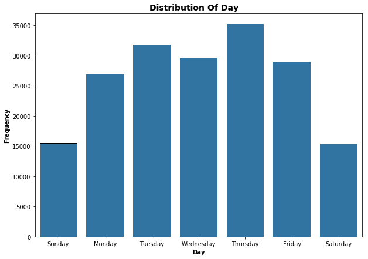

## Bike Service Hours for both users

> Most Subscribers use the service at peak hours between 8 and 17 (5pm).

> Customers have more flexible time, mostly used in the afternoon.

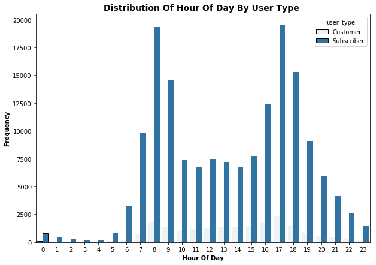

## Bike service usage per day for both users

> Subscribers tend to use the service during the week, probably for work related purposes while Customers have more flexible time.

> Customers have a slight increase on thursday and friday but the rest of the day is relatively the same

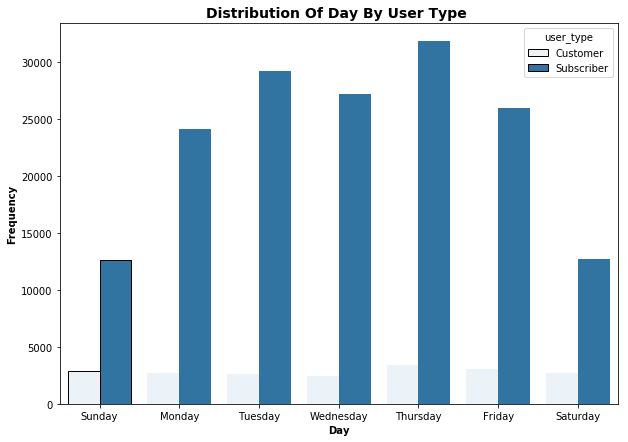

## Bike service usage per hour for both users

> Subscribers seem to have a lot more stable use of the bikes than the Customers although Customer usage is also high.

> Its interesting that Customers have a very high average duration around 3AM which is higher than every other hour

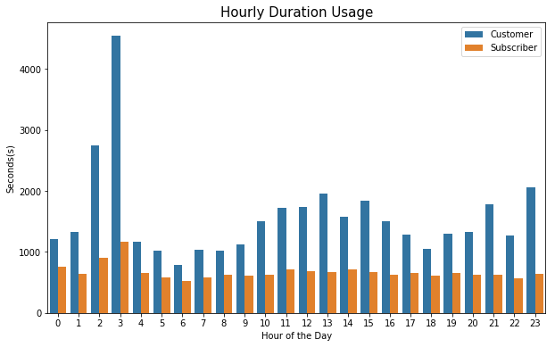

## Amont of time spent per day based on User Type

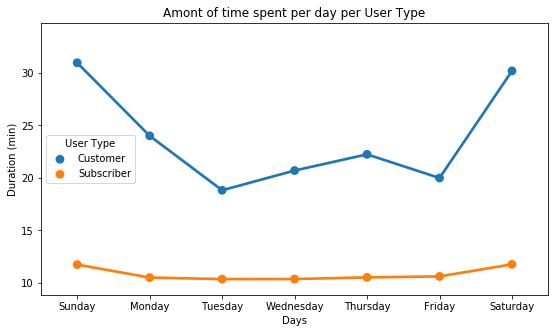